# Sign-Language-Recognition-System

## Sign Language Recognition System

- Introduction
- Data Processing
- Feature Engineering
  - Adding More Features
- Model Selection
  - Log likelihood
  - Visualize Hidden States
  - Cross-validation
  - DIC and BIC
  - Model Comparision
- Recognizer
  - Select the Best Model
- Resources

## Introduction

[ go back to the top ]

The goal of this project is to build a word recognizer for American Sign Language video sequences. In particular, this project employs [hidden Markov models (HMM's)](https://en.wikipedia.org/wiki/Hidden_Markov_model) to analyze a series of measurements taken from videos of American Sign Language (ASL) collected for research (see the [RWTH-BOSTON-104 Database](http://www-i6.informatik.rwth-aachen.de/~dreuw/database-rwth-boston-104.php)). In this video, the right-hand x and y locations are plotted as the speaker signs the sentence.

[figure not shown]

There are three main steps in this project:

- Derive a variety of feature sets from training data
- Implement three different model selection criterion to determine the optimal number of hidden states for each word model
- Implement the recognizer and compare the effects between different combinations of feature sets and model selection criteria

## Data Processing

[ go back to the top ]

A data handler designed for this database is provided by [Udacity](https://github.com/udacity/AIND-Recognizer/blob/master/asl_data.py) as the `AslDb` class in the `asl_data` module. This handler creates the initial [pandas](http://pandas.pydata.org/pandas-docs/stable/) dataframe from the corpus of data included in the `data` directory as well as dictionaries suitable for extracting data in a format friendly to the [hmmlearn](https://hmmlearn.readthedocs.io/en/latest/) library.

To start, let's set up the initial database and select an example set of features for the training set.

```python
import numpy as np
import pandas as pd
from asl_data import AslDb
import timeit

%matplotlib inline
import math
from matplotlib import (cm, pyplot as plt, mlab)

from asl_utils import test_features_tryit
from asl_utils import test_std_tryit
```

```python
asl = AslDb() # initializes the database
asl.df.head() # displays the first five rows of the asl database, indexed by video and frame
```

| video | frame | left-x | left-y | right-x | right-y | nose-x | nose-y | speaker |
| --- | --- | --- | --- | --- | --- | --- | --- | --- |
| 98 | 0 | 149 | 181 | 170 | 175 | 161 | 62 | woman-1 |
|  | 1 | 149 | 181 | 170 | 175 | 161 | 62 | woman-1 |
|  | 2 | 149 | 181 | 170 | 175 | 161 | 62 | woman-1 |
|  | 3 | 149 | 181 | 170 | 175 | 161 | 62 | woman-1 |
|  | 4 | 149 | 181 | 170 | 175 | 161 | 62 | woman-1 |

```python
asl.df.loc[98,1]  # look at the data available for an individual frame
```

```
left-x         149
left-y         181
right-x        170
right-y        175
nose-x         161
nose-y          62
speaker    woman-1
Name: (98, 1), dtype: object
```

The frame represented by video 98, frame 1 is shown here:

[figure not shown]

## Feature Engineering

[ go back to the top ]

The objective of feature selection when training a model is to choose the most relevant variables while keeping the model as simple as possible, thus reducing training time. We can use the raw features already provided or derive our own and add columns to the pandas dataframe `asl.df` for selection. As an example, in the next cell a feature named `'grnd-ry'` is added. This feature is the difference between the right-hand y value and the nose y value, which serves as the "ground" right y value.

```python
asl.df['grnd-ry'] = asl.df['right-y'] - asl.df['nose-y']
asl.df.head()  # the new feature 'grnd-ry' is now in the frames dictionary
```

| video | frame | left-x | left-y | right-x | right-y | nose-x | nose-y | speaker | grnd-ry |
| --- | --- | --- | --- | --- | --- | --- | --- | --- | --- |
| 98 | 0 | 149 | 181 | 170 | 175 | 161 | 62 | woman-1 | 113 |
|  | 1 | 149 | 181 | 170 | 175 | 161 | 62 | woman-1 | 113 |
|  | 2 | 149 | 181 | 170 | 175 | 161 | 62 | woman-1 | 113 |
|  | 3 | 149 | 181 | 170 | 175 | 161 | 62 | woman-1 | 113 |
|  | 4 | 149 | 181 | 170 | 175 | 161 | 62 | woman-1 | 113 |

We added a few more columns - 'grnd-rx', 'grnd-ly', 'grnd-lx' - to represent differences between hand and nose locations.

```python
for i,j,k in zip(['grnd-ry', 'grnd-rx', 'grnd-ly', 'grnd-lx'],
                 ['right-y', 'right-x', 'left-y', 'left-x'],
                 ['nose-y', 'nose-x', 'nose-y', 'nose-x']):
    asl.df[i] = asl.df[j] - asl.df[k]
```

```python
# collect the features into a list
features_ground = ['grnd-rx','grnd-ry','grnd-lx','grnd-ly']
 #show a single set of features for a given (video, frame) tuple
print("for a given tuple, what is the set of features")
asl.df.loc[98,1]
```

```
for a given tuple, what is the set of features
```

```
left-x         149
left-y         181
right-x        170
right-y        175
nose-x         161
nose-y          62
speaker    woman-1
grnd-ry        113
grnd-rx          9
grnd-ly        119
grnd-lx        -12
Name: (98, 1), dtype: object
```

Now that we have a feature list defined, we can pass that list to the `build_training` method to collect the features for all the words in the training set. Each word in the training set has multiple examples from various videos. Below we can see the unique words that have been loaded into the training set:

```python
training = asl.build_training(features_ground)
print("Training words: {}".format(training.words))
```

```
Training words: ['JOHN', 'WRITE', 'HOMEWORK', 'IX-1P', 'SEE', 'YESTERDAY', 'IX', 'LOVE', 'MARY', 'CAN', 'GO', 'GO1', 'FUTURE', 'GO2', 'PARTY', 'FUTURE1', 'HIT', 'BLAME', 'FRED', 'FISH', 'WONT', 'EAT', 'BUT', 'CHICKEN', 'VEGETABLE', 'CHINA', 'PEOPLE', 'PREFER', 'BROCCOLI', 'LIKE', 'LEAVE', 'SAY', 'BU…
```

The training data in `training` is an object of class `WordsData` defined in the `asl_data` module. in addition to the `words` list, data can be accessed with the `get_all_sequences`, `get_all_Xlengths`, `get_word_sequences`, and `get_word_Xlengths` methods. We need the `get_word_Xlengths` method to train multiple sequences with the `hmmlearn` library. In the following example, notice that there are two lists; the first is a concatenation of all the sequences(the X portion) and the second is a list of the sequence lengths(the Lengths portion).

```python
training.get_word_Xlengths('CHOCOLATE')
```

```
(array([[-11,  48,   7, 120],
        [-11,  48,   8, 109],
        [ -8,  49,  11,  98],
        [ -7,  50,   7,  87],
        [ -4,  54,   7,  77],
        [ -4,  54,   6,  69],
        [ -4,  54,   6,  69],
        [-13,  52,   6,  69],
        [-13,  52,   6,  69],
        [ -8,  51,   6,  69],
        [ -8,  51,   6,  69],
        [ -8,  51,   6,  69],
        [ -8,  51,   6,  69],
        [ -8,  51,   6,  69],
        [-10,  59,   7,  71],
        [-15,  64,   9,  77],
        [-17,  75,  13,  81],
        [ -4,  48,  -4, 113],
        [ -2,  53,  -4, 113],
        [ -4,  55,   2,  98],
        [ -4,  58,   2,  98],
        [ -1,  59,   2,  89],
        [ -1,  59,  -1,  84],
        [ -1,  59,  -1,  84],
        [ -7,  63,  -1,  84],
        [ -7,  63,  -1,  84],
        [ -7,  63,   3,  83],
        [ -7,  63,   3,  83],
        [ -7,  63,   3,  83],
        [ -7,  63,   3,  83],
        [ -7,  63,   3,  83],
        [ -7,  63,   3,  83],
        [ -7,  63,   3,  83],
        [ -4,  70,   3,  83],
        [ -4,  70,   3,  83],
        [ -2,  73,   5,  90],
        [ -3,  79,  -4,  96],
        [-15,  98,  13, 135],
        [ -6,  93,  12, 128],
        [ -2,  89,  14, 118],
        [  5,  90,  10, 108],
        [  4,  86,   7, 105],
        [  4,  86,   7, 105],
        [  4,  86,  13, 100],
        [ -3,  82,  14,  96],
        [ -3,  82,  14,  96],
        [  6,  89,  16, 100],
        [  6,  89,  16, 100],
        [  7,  85,  17, 111]]), [17, 20, 12])
```

So far we have a simple feature set that is enough to get started modeling. However, we might get better results if we manipulate the raw values a bit more, so we will go ahead and set up some other options now for experimentation later. For example, we could normalize each speaker's range of motion with grouped statistics using [Pandas stats](http://pandas.pydata.org/pandas-docs/stable/api.html#api-dataframe-stats) functions and [pandas groupby](http://pandas.pydata.org/pandas-docs/stable/generated/pandas.DataFrame.groupby.html). Below is an example for finding the means of all speaker subgroups.

```python
df_means = asl.df.groupby('speaker').mean()
df_means
```

| speaker | left-x | left-y | right-x | right-y | nose-x | nose-y | grnd-ry | grnd-rx | grnd-ly | grnd-lx |
| --- | --- | --- | --- | --- | --- | --- | --- | --- | --- | --- |
| man-1 | 206.248203 | 218.679449 | 155.464350 | 150.371031 | 175.031756 | 61.642600 | 88.728430 | -19.567406 | 157.036848 | 31.216447 |
| woman-1 | 164.661438 | 161.271242 | 151.017865 | 117.332462 | 162.655120 | 57.245098 | 60.087364 | -11.637255 | 104.026144 | 2.006318 |
| woman-2 | 183.214509 | 176.527232 | 156.866295 | 119.835714 | 170.318973 | 58.022098 | 61.813616 | -13.452679 | 118.505134 | 12.895536 |

To select a mean that matches by speaker, use the pandas [map](http://pandas.pydata.org/pandas-docs/stable/generated/pandas.Series.map.html) method:

```python
for i,j in zip(['left-x-mean', 'left-y-mean', 'right-x-mean', 'right-y-mean'],
                 ['left-x', 'left-y', 'right-x', 'right-y']):
    asl.df[i] = asl.df['speaker'].map(df_means[j])

asl.df.head()
```

| video | frame | left-x | left-y | right-x | right-y | nose-x | nose-y | speaker | grnd-ry | grnd-rx | grnd-ly | grnd-lx | left-x-mean | left-y-mean | right-x-mean | right-y-mean |
| --- | --- | --- | --- | --- | --- | --- | --- | --- | --- | --- | --- | --- | --- | --- | --- | --- |
| 98 | 0 | 149 | 181 | 170 | 175 | 161 | 62 | woman-1 | 113 | 9 | 119 | -12 | 164.661438 | 161.271242 | 151.017865 | 117.332462 |
|  | 1 | 149 | 181 | 170 | 175 | 161 | 62 | woman-1 | 113 | 9 | 119 | -12 | 164.661438 | 161.271242 | 151.017865 | 117.332462 |
|  | 2 | 149 | 181 | 170 | 175 | 161 | 62 | woman-1 | 113 | 9 | 119 | -12 | 164.661438 | 161.271242 | 151.017865 | 117.332462 |
|  | 3 | 149 | 181 | 170 | 175 | 161 | 62 | woman-1 | 113 | 9 | 119 | -12 | 164.661438 | 161.271242 | 151.017865 | 117.332462 |
|  | 4 | 149 | 181 | 170 | 175 | 161 | 62 | woman-1 | 113 | 9 | 119 | -12 | 164.661438 | 161.271242 | 151.017865 | 117.332462 |

We added a column `df_std` with standard deviations grouped by speaker.

```python
# TODO Create a dataframe named `df_std` with standard deviations grouped by speaker
df_std = asl.df.groupby('speaker').std()
# test the code
test_std_tryit(df_std)
```

```
df_std
```

| speaker | left-x | left-y | right-x | right-y | nose-x | nose-y | grnd-ry | grnd-rx | grnd-ly | grnd-lx | left-x-mean | left-y-mean | right-x-mean | right-y-mean |
| --- | --- | --- | --- | --- | --- | --- | --- | --- | --- | --- | --- | --- | --- | --- |
| man-1 | 15.154425 | 36.328485 | 18.901917 | 54.902340 | 6.654573 | 5.520045 | 53.487999 | 20.269032 | 36.572749 | 15.080360 | 0.0 | 0.0 | 0.0 | 0.0 |
| woman-1 | 17.573442 | 26.594521 | 16.459943 | 34.667787 | 3.549392 | 3.538330 | 33.972660 | 16.764706 | 27.117393 | 17.328941 | 0.0 | 0.0 | 0.0 | 0.0 |
| woman-2 | 15.388711 | 28.825025 | 14.890288 | 39.649111 | 4.099760 | 3.416167 | 39.128572 | 16.191324 | 29.320655 | 15.050938 | 0.0 | 0.0 | 0.0 | 0.0 |

Correct!

```python
for i,j in zip(['left-x-std', 'left-y-std', 'right-x-std', 'right-y-std'],
                 ['left-x', 'left-y', 'right-x', 'right-y']):
    asl.df[i] = asl.df['speaker'].map(df_std[j])
```

### Adding More Features

[ go back to the top ]

We'll add more features based on the following calculations.

- normalized Cartesian coordinates
  - use *mean* and *standard deviation* statistics and the [standard score](https://en.wikipedia.org/wiki/Standard_score) equation to account for speakers with different heights and arm length
- polar coordinates
  - calculate polar coordinates with [Cartesian to polar equations](https://en.wikipedia.org/wiki/Polar_coordinate_system#Converting_between_polar_and_Cartesian_coordinates)
  - use the [np.arctan2](https://docs.scipy.org/doc/numpy-1.10.0/reference/generated/numpy.arctan2.html) function and *swap the x and y axes* to move the $0$ to $2\pi$ discontinuity to 12 o'clock instead of 3 o'clock; in other words, the normal break in radians value from $0$ to $2\pi$ occurs directly to the left of the speaker's nose, which may be in the signing area and interfere with results. By swapping the x and y axes, that discontinuity move to directly above the speaker's head, an area not generally used in signing.
- delta difference
  - use the difference in values between one frame and the next frames as features
- custom features
  - use a different method to normalize/rescale the data. The range of each feature is between 0 and 1 after this rescaling. There are two major benefits using this method: one is for data visulization, rescaling the data makes interpretation easier and clearer. The other one is that it helps HMMs converge faster as HMMs uses up lots of memory and iterative Baum-Welch algorithm is a approach similar to gradient descent.

```python
# add features for normalized by speaker values of left, right, x, y
# Name these 'norm-rx', 'norm-ry', 'norm-lx', and 'norm-ly'
# using Z-score scaling (X-Xmean)/Xstd
features_norm = ['norm-rx', 'norm-ry', 'norm-lx', 'norm-ly']
for i,j,k,l in zip(features_norm,
                 ['left-x', 'left-y', 'right-x', 'right-y'],
                 ['left-x-mean', 'left-y-mean', 'right-x-mean', 'right-y-mean'],
                 ['left-x-std', 'left-y-std', 'right-x-std', 'right-y-std']):
    asl.df[i] = (asl.df[j] - asl.df[k]) / (asl.df[l])
```

```python
# add features for polar coordinate values where the nose is the origin
# Name these 'polar-rr', 'polar-rtheta', 'polar-lr', and 'polar-ltheta'
# Note that 'polar-rr' and 'polar-rtheta' refer to the radius and angle
features_polar = ['polar-rr', 'polar-rtheta', 'polar-lr', 'polar-ltheta']
for i,j,k in zip(['polar-rr', 'polar-lr'],
                 ['grnd-ry',  'grnd-ly'],
                 ['grnd-rx', 'grnd-lx']):
    asl.df[i] = np.sqrt(np.square(asl.df[j]) + np.square(asl.df[k]))

for i,j,k in zip(['polar-rtheta', 'polar-ltheta'],
                 ['grnd-rx', 'grnd-lx'],
                 ['grnd-ry',  'grnd-ly']):
    asl.df[i] = np.arctan2(asl.df[j], asl.df[k])
```

```python
# add features for left, right, x, y differences by one time step,
# i.e. the "delta" values discussed in the lecture
# Name these 'delta-rx', 'delta-ry', 'delta-lx', and 'delta-ly'
features_delta = ['delta-rx', 'delta-ry', 'delta-lx', 'delta-ly']
asl.df = asl.df.reset_index().sort_values(by = ["video", "frame"])
```

```python
temp = asl.df[features_ground].diff()
temp.columns = features_delta
asl.df = asl.df.join(temp).fillna(0)
asl.df.loc[asl.df["frame"] == 0, features_delta] = 0
asl.df.set_index(["video", "frame"], inplace=True)
```

```python
# add features of your own design, which may be a combination of the above or something else
# Name these whatever you would like
# define a list named 'features_custom' for building the training set
features_custom = ['scale-lx', 'scale-ly', 'scale-rx', 'scale-ry']
cols = ['left-x', 'left-y', 'right-x', 'right-y']
min_cols = ['left-x-min', 'left-y-min', 'right-x-min', 'right-y-min']
range_cols = ['left-x-range', 'left-y-range', 'right-x-range', 'right-y-range']

df_max = asl.df.groupby('speaker')[cols].max()
df_min = asl.df.groupby('speaker')[cols].min()
df_range = df_max - df_min

for i,j in zip(min_cols, cols):
    asl.df[i] = asl.df['speaker'].map(df_min[j])
for i,j in zip(range_cols, cols):
    asl.df[i] = asl.df['speaker'].map(df_range[j])
for i,j,k,l in zip(features_custom, cols, min_cols, range_cols):
    asl.df[i] = (asl.df[j] - asl.df[k]) / (asl.df[l])
```

## Model Selection

[ go back to the top ]

Now that we have built a training set with sequence data, we can "train" models for each word. As a simple starting example, we train a single word using Gaussian hidden Markov models (HMM). By using the `fit` method during training, the [Baum-Welch Expectation-Maximization](https://en.wikipedia.org/wiki/Baum%E2%80%93Welch_algorithm) (EM) algorithm is invoked iteratively to find the best estimate for the model *for the number of hidden states specified* from a group of sample seequences. For this example, we *assume* the correct number of hidden states is 3, but that is just a guess. How do we know what the "best" number of states for training is? We will need to find some model selection technique to choose the best parameter.

The objective of Model Selection is to tune the number of states for each word HMM prior to testing on unseen data. In this section we will explore three methods:

- Log likelihood using cross-validation folds (CV)
- Bayesian Information Criterion (BIC)
- Discriminative Information Criterion (DIC)

We will train each word in the training set with a range of values for the number of hidden states, and then score these alternatives with the model selector, choosing the "best" according to each strategy.

### Log likelihood

[ go back to the top ]

```python
import warnings
from hmmlearn.hmm import GaussianHMM

def train_a_word(word, num_hidden_states, features):
    warnings.filterwarnings("ignore", category=DeprecationWarning)
    training = asl.build_training(features)
    X, lengths = training.get_word_Xlengths(word)
    model = GaussianHMM(n_components=num_hidden_states, n_iter=1000).fit(X, lengths)
    logL = model.score(X, lengths)
    return model, logL

demoword = 'BOOK'
model, logL = train_a_word(demoword, 3, features_ground)
print("Number of states trained in model for {} is {}".format(demoword, model.n_components))
print("logL = {}".format(logL))
```

```
Number of states trained in model for BOOK is 3
logL = -2331.1138127433187
```

The HMM model has been trained and information can be pulled from the model, including means and variances for each feature and hidden state. The [log likelihood](http://math.stackexchange.com/questions/892832/why-we-consider-log-likelihood-instead-of-likelihood-in-gaussian-distribution) for any individual sample or group of samples can also be calculated with the `score` method.

```python
def show_model_stats(word, model):
    print("Number of states trained in model for {} is {}".format(word, model.n_components))
    variance=np.array([np.diag(model.covars_[i]) for i in range(model.n_components)])
    for i in range(model.n_components):  # for each hidden state
        print("hidden state #{}".format(i))
        print("mean = ", model.means_[i])
        print("variance = ", variance[i])
        print()

show_model_stats(demoword, model)
```

```
Number of states trained in model for BOOK is 3
hidden state #0
mean =  [-3.46504869 50.66686933 14.02391587 52.04731066]
variance =  [49.12346305 43.04799144 39.35109609 47.24195772]

hidden state #1
mean =  [-11.45300909  94.109178    19.03512475 102.2030162 ]
variance =  [ 77.403668   203.35441965  26.68898447 156.12444034]

hidden state #2
mean =  [-1.12415027 69.44164191 17.02866283 77.7231196 ]
variance =  [19.70434594 16.83041492 30.51552305 11.03678246]
```

Experiment by changing the feature set, word, and/or num_hidden_states values in the next cell to see changes in values.

```python
my_testword = 'CHOCOLATE'
for i in range(3,8):
    model, logL = train_a_word(my_testword, i, features_ground) # Experiment here with different parameters
    show_model_stats(my_testword, model)
    print("logL = {}\n".format(logL))
```

```
Number of states trained in model for CHOCOLATE is 3
hidden state #0
mean =  [  0.58333333  87.91666667  12.75       108.5       ]
variance =  [ 39.41055556  18.74388889   9.855      144.4175    ]

hidden state #1
mean =  [-9.30211403 55.32333876  6.92259936 71.24057775]
variance =  [16.16920957 46.50917372  3.81388185 15.79446427]

hidden state #2
mean =  [-5.40587658 60.1652424   2.32479599 91.3095432 ]
variance =  [  7.95073876  64.13103127  13.68077479 129.5912395 ]

logL = -601.3291470028628

Number of states trained in model for CHOCOLATE is 4
hidden state #0
mean =  [ -6.37712306  51.09867416   3.64009161 104.46268173]
variance =  [ 10.28220014  12.44316166  27.33390004 106.91029392]

hidden state #1
mean =  [  0.58333258  87.91666611  12.75000001 108.49999882]
variance =  [ 39.4105671   18.74389523   9.85499958 144.41752618]

hidden state #2
mean =  [-9.23835975 55.307463    6.92298661 71.30538347]
variance =  [16.30887738 45.97071639  3.76856896 15.98215464]

hidden state #3
mean =  [-4.93681705 64.73171915  1.62598519 84.91459657]
variance =  [ 6.1617479  28.36616959  5.47102461 13.11696032]

logL = -565.1243334331184

Number of states trained in model for CHOCOLATE is 5
hidden state #0
mean =  [-4.93673736 64.73126904  1.62601029 84.91542811]
variance =  [ 6.16147276 28.36727822  5.4706657  13.12675543]

hidden state #1
mean =  [  3.32089022  86.11784619  12.66977977 102.36987409]
variance =  [12.48273231  7.43528515 12.86407411 24.73804616]

hidden state #2
mean =  [ -6.37753172  51.09767101   3.64019095 104.46455217]
variance =  [ 10.28279876  12.43850367  27.33782827 106.89825397]

hidden state #3
mean =  [-9.23826304 55.30740641  6.92298855 71.30558162]
variance =  [16.30897315 45.96991798  3.76848558 15.98402053]

hidden state #4
mean =  [ -7.70665738  93.36393433  12.99292645 127.06351815]
variance =  [29.53966949 13.52107768  0.66764483 48.4385572 ]

logL = -544.249011471228
```

```
Number of states trained in model for CHOCOLATE is 6
hidden state #0
mean =  [-5.63313599 63.45870349  1.77445094 83.30638727]
variance =  [4.96369411 9.67620112 3.40099917 0.21328753]

hidden state #1
mean =  [  3.32090355  86.11783896  12.66977644 102.3698349 ]
variance =  [12.48269263  7.43528296 12.86410192 24.73749575]

hidden state #2
mean =  [ -5.58233089  52.22612029   3.78156308 100.13776713]
variance =  [ 11.07955304  16.07662505  23.16019139 165.33172872]

hidden state #3
mean =  [-8.22222323 51.88888839  6.         69.        ]
variance =  [9.06283744e+00 1.43320916e+00 1.11111138e-03 1.11111138e-03]

hidden state #4
mean =  [ -7.70661404  93.3639012   12.99293409 127.06344932]
variance =  [29.53969267 13.5211196   0.66764747 48.43881357]

hidden state #5
mean =  [-9.36574718 69.99999631  5.98096981 82.99999993]
variance =  [36.99081588 54.05693324 31.85572684 79.89197873]

logL = -425.6059034604848

Number of states trained in model for CHOCOLATE is 7
hidden state #0
mean =  [-2.49479102 57.29183088  1.77599686 88.57136532]
variance =  [ 2.23316721  4.36678843  7.40442932 64.21103614]

hidden state #1
mean =  [  3.32090356  86.11783896  12.66977644 102.36983489]
variance =  [12.48269262  7.43528296 12.86410193 24.73749564]

hidden state #2
mean =  [-8.22222292 51.88888854  6.         69.        ]
variance =  [9.06283808e+00 1.43320938e+00 1.11111130e-03 1.11111130e-03]

hidden state #3
mean =  [-9.31918091 69.99999519  5.95509939 82.99999993]
variance =  [36.91748346 53.58780689 31.65571582 79.19863428]

hidden state #4
mean =  [ -7.70661403  93.36390119  12.99293409 127.06344931]
variance =  [29.53969267 13.52111961  0.66764747 48.43881362]

hidden state #5
mean =  [ -7.21707455  49.29893395   4.24742906 106.60020757]
variance =  [ 10.98219468   3.13222131  34.80659831 121.67015147]

hidden state #6
mean =  [-6.47159952 64.23292752  2.26774908 83.18306273]
variance =  [1.30691676 7.11131478 2.39372769 0.1504662 ]

logL = -405.214073324148
```

The log likelihood increases as the number of hidden states increases.

### Visualize Hidden States

[ go back to the top ]

We can plot the means and variances for each state and feature. We vary the number of states trained for the HMM model and examine the variances.

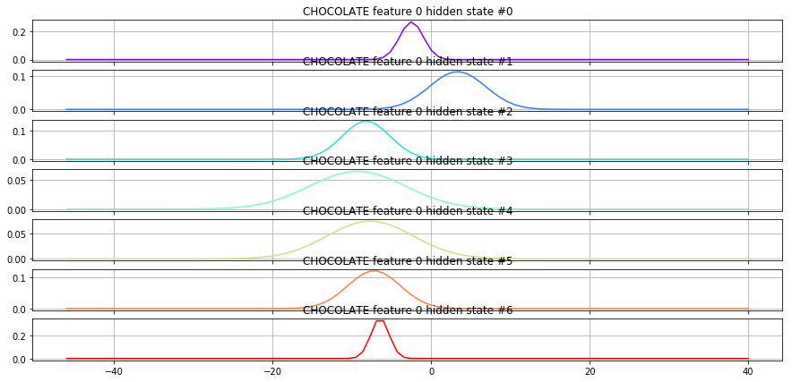

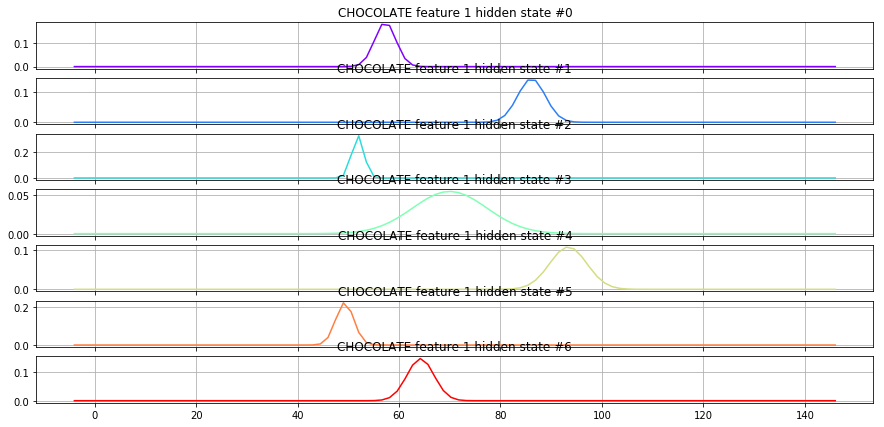

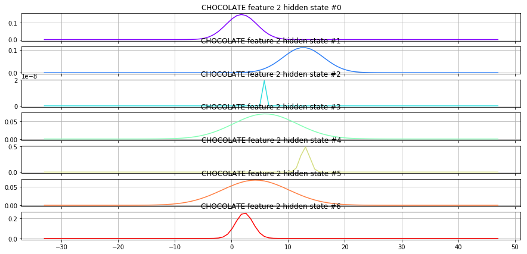

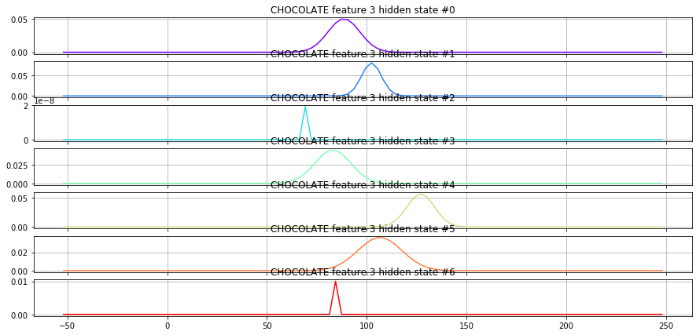

```python
def visualize(word, model):
    """ visualize the input model for a particular word """
    variance=np.array([np.diag(model.covars_[i]) for i in range(model.n_components)])
    figures = []
    for parm_idx in range(len(model.means_[0])):
        xmin = int(min(model.means_[:,parm_idx]) - max(variance[:,parm_idx]))
        xmax = int(max(model.means_[:,parm_idx]) + max(variance[:,parm_idx]))
        fig, axs = plt.subplots(model.n_components, sharex=True, sharey=False,
                                figsize = (15,7))
        colours = cm.rainbow(np.linspace(0, 1, model.n_components))
        for i, (ax, colour) in enumerate(zip(axs, colours)):
            x = np.linspace(xmin, xmax, 100)
            mu = model.means_[i,parm_idx]
            sigma = math.sqrt(np.diag(model.covars_[i])[parm_idx])
            ax.plot(x, mlab.normpdf(x, mu, sigma), c=colour)
            ax.set_title("{} feature {} hidden state #{}".format(word, parm_idx, i))

            ax.grid(True)
        figures.append(plt)
    for p in figures:
        p.show()

visualize(my_testword, model)
```

### Cross-validation

[ go back to the top ]

If we simply score the model with the Log Likelihood calculated from the feature sequences it has been trained on, we should expect that more complex models will have higher likelihoods. However, that doesn't tell us which would have a better likelihood score on unseen data. The model will likely be overfit as complexity is added. To estimate which topology model is better using only the training data, we can compare scores using cross-validation. One technique for cross-validation is to break the training set into "folds" and rotate which fold is left out of training. The "left out" fold scored. This gives us a proxy method of finding the best model to use on "unseen data". In the following example, a set of word sequences is broken into three folds using the [scikit-learn Kfold](http://scikit-learn.org/stable/modules/generated/sklearn.model_selection.KFold.html) class object.

```python
from sklearn.model_selection import KFold

training = asl.build_training(features_ground) # Experiment here with different feature sets
word = 'VEGETABLE' # Experiment here with different words
word_sequences = training.get_word_sequences(word)
split_method = KFold()
for cv_train_idx, cv_test_idx in split_method.split(word_sequences):
    print("Train fold indices:{} Test fold indices:{}".format(cv_train_idx, cv_test_idx))  # view indices of the folds
```

```
Train fold indices:[2 3 4 5] Test fold indices:[0 1]
Train fold indices:[0 1 4 5] Test fold indices:[2 3]
Train fold indices:[0 1 2 3] Test fold indices:[4 5]
```

Note that in order to run `hmmlearn` training using the X,lengths tuples on the new folds, subsets must be combined based on the indices given for the folds.

### DIC and BIC

[ go back to the top ]

Scoring model topologies with **Bayesian Information Criterion (BIC)** balances fit and complexity within the training set for each word. In the BIC equation, a penalty term penalizes complexity to avoid overfitting, so that it is not necessary to also use cross-validation in the selection process. There are a number of references on the internet for this criterion. These [slides](http://www2.imm.dtu.dk/courses/02433/doc/ch6_slides.pdf) include a formula that will be helpful for our implementation.

The advantages of scoring model topologies with **Discriminative Information Criterion (DIC)** over BIC are presented by Alain Biem in this [reference](http://citeseerx.ist.psu.edu/viewdoc/download?doi=10.1.1.58.6208&rep=rep1&type=pdf) (also found [here](https://pdfs.semanticscholar.org/ed3d/7c4a5f607201f3848d4c02dd9ba17c791fc2.pdf)). DIC scores the discriminant ability of a training set for one word against competing words. Instead of a penalty term for complexity, it provides a penalty if model liklihoods for non-matching words are too similar to model likelihoods for the correct word in the word set.

Let's visualize the time spent on training different models for 5 words - 'FISH', 'BOOK', 'VEGETABLE', 'FUTURE' and 'JOHN'.

```python
# autoreload for automatically reloading changes made in my_model_selectors and my_recognizer
%load_ext autoreload
%autoreload 2

words_to_train = ['FISH', 'BOOK', 'VEGETABLE', 'FUTURE', 'JOHN']
training = asl.build_training(features_ground)  # Experiment here with different feature sets defined in part 1
sequences = training.get_all_sequences()
Xlengths = training.get_all_Xlengths()
```

```python
# Implement SelectorCV in my_model_selector.py
from my_model_selectors import SelectorCV
cv_dict = {}
for word in words_to_train:
    start = timeit.default_timer()
    model = SelectorCV(sequences, Xlengths, word,
                    min_n_components=2, max_n_components=15, random_state = 14).select()
    end = timeit.default_timer()-start
    if model is not None:
        cv_dict[word] = (model.n_components, end)
#         print("Training complete for {} with {} states with time {} seconds".format(word, model.n_components, end))
    else:
        print("Training failed for {}".format(word))
```

```python
# Implement SelectorBIC in module my_model_selectors.py
from my_model_selectors import SelectorBIC
bic_dict = {}
for word in words_to_train:
    start = timeit.default_timer()
    model = SelectorBIC(sequences, Xlengths, word,
                    min_n_components=2, max_n_components=15, random_state = 14).select()
    end = timeit.default_timer()-start
    if model is not None:
        bic_dict[word] = (model.n_components, end)
#         print("Training complete for {} with {} states with time {} seconds".format(word, model.n_components, end))
    else:
        print("Training failed for {}".format(word))
```

```python
# Implement SelectorDIC in module my_model_selectors.py
from my_model_selectors import SelectorDIC
dic_dict = {}
for word in words_to_train:
    start = timeit.default_timer()
    model = SelectorDIC(sequences, Xlengths, word,
                    min_n_components=2, max_n_components=15, random_state = 14).select()
    end = timeit.default_timer()-start
    if model is not None:
        dic_dict[word] = (model.n_components, end)
#         print("Training complete for {} with {} states with time {} seconds".format(word, model.n_components, end))
    else:
        print("Training failed for {}".format(word))
```

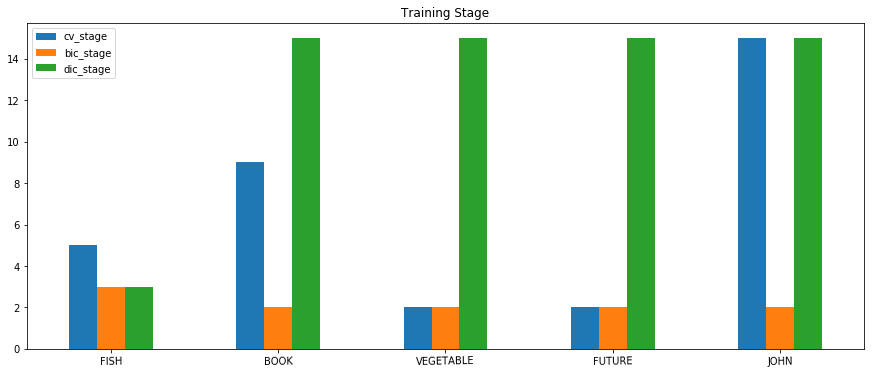

```python
time_df = pd.concat([pd.DataFrame(cv_dict),
           pd.DataFrame(bic_dict),
           pd.DataFrame(dic_dict)]).T
time_df.columns = ["cv_stage", "CV", "bic_stage", "BIC", "dic_stage", "DIC"]

plot = time_df[["cv_stage", "bic_stage", "dic_stage"]].plot(kind='bar', stacked=False, rot=1,
                                          figsize=(15, 6),
                                          title="Training Stage")
```

```
Text(0.5,1,'Training Time by Technique')
```

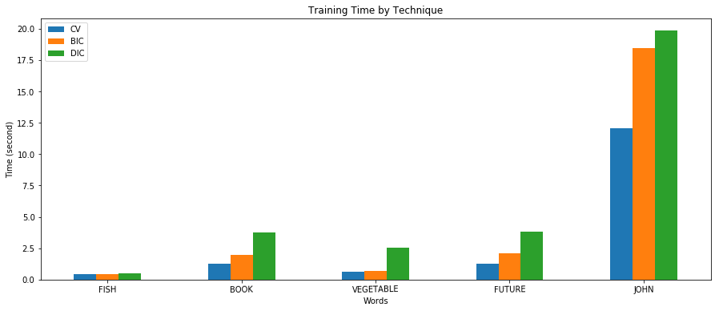

```python
plot = time_df[["CV", "BIC", "DIC"]].plot(kind='bar', stacked=False, rot=1,
                                          figsize=(15, 6),
                                          title="Training Time")
plot.set_xlabel("Words")
plot.set_ylabel("Time (second)")
plot.set_title("Training Time by Technique")
```

### Model Comparision

[ go back to the top ]

Cross Validation (CV)

BIC

DIC

- Advantages
  - better performance than BIC
  - decreases error rates by >18% compared to BIC ( http://citeseerx.ist.psu.edu/viewdoc/download?doi=10.1.1.58.6208&rep=rep1&type=pdf)
- Disadvantages
  - DIC performance of resulting models is usually higher than BIC (surprisingly slower in our results though)
  - have more parameters than BIC
  - is a better approach for classification problem

## Recognizer

[ go back to the top ]

```python
from my_model_selectors import SelectorConstant

def train_all_words(features, model_selector):
    training = asl.build_training(features)
    # Experiment here with different feature sets defined in part 1
    sequences = training.get_all_sequences()
    Xlengths = training.get_all_Xlengths()
    model_dict = {}
    for word in training.words:
        model = model_selector(sequences, Xlengths, word,
                        n_constant=3).select()
        model_dict[word]=model
    return model_dict

models = train_all_words(features_ground, SelectorConstant)
print("Number of word models returned = {}".format(len(models)))
```

```
Number of word models returned = 112
```

The `build_test` method in `ASLdb` is similar to the `build_training` method already presented, but there are a few differences:

- the object is type `SinglesData`
- the internal dictionary keys are the index of the test word rather than the word itself
- the getter methods are `get_all_sequences`, `get_all_Xlengths`, `get_item_sequences` and `get_item_Xlengths`

```python
test_set = asl.build_test(features_ground)
print("Number of test set items: {}".format(test_set.num_items))
print("Number of test set sentences: {}".format(len(test_set.sentences_index)))
```

```
Number of test set items: 178
Number of test set sentences: 40
```

### Select the Best Model

[ go back to the top ]

```python
# implement the recognize method in my_recognizer
from my_recognizer import recognize
from asl_utils import show_errors
res = pd.DataFrame(['features_ground', 'features_norm', 'features_polar',
                    'features_delta', 'features_custom'])
# Choose a feature set and model selector
features = {
    'features_ground': features_ground,
    'features_norm': features_norm,
    'features_polar': features_polar,
    'features_delta': features_delta,
    'features_custom': features_custom}
```

```python
def get_results(model, model_name):
    print("Results of " + model_name)
    error = []
    for name, f in features.items():
        models = train_all_words(f, model)
        test_set = asl.build_test(f)
        probabilities, guesses = recognize(models, test_set)
        print("Results for Feature Set: %r" % name)
        error.append(show_errors(guesses, test_set))
    return error
```

```python
 # Recognize the test set and display the result with the show_errors method
# Choose a feature set and model selector
for m,n in zip(['BIC', 'DIC', 'CV'],
               [SelectorBIC, SelectorDIC, SelectorCV]):
    res[m] = get_results(n, m)
```

```
Results of BIC
Results for Feature Set: 'features_ground'

**** WER = 0.6348314606741573
Total correct: 65 out of 178
Results for Feature Set: 'features_norm'

**** WER = 0.6629213483146067
Total correct: 60 out of 178
Results for Feature Set: 'features_polar'

**** WER = 0.6404494382022472
Total correct: 64 out of 178
Results for Feature Set: 'features_delta'

**** WER = 0.6123595505617978
Total correct: 69 out of 178
Results for Feature Set: 'features_custom'

**** WER = 0.6910112359550562
Total correct: 55 out of 178
Results of DIC
Results for Feature Set: 'features_ground'

**** WER = 0.5786516853932584
Total correct: 75 out of 178
Results for Feature Set: 'features_norm'

**** WER = 0.6235955056179775
Total correct: 67 out of 178
Results for Feature Set: 'features_polar'

**** WER = 0.5449438202247191
Total correct: 81 out of 178
Results for Feature Set: 'features_delta'

**** WER = 0.6292134831460674
Total correct: 66 out of 178
Results for Feature Set: 'features_custom'

```

[output cut: 8 more lines]

```

**** WER = 0.6741573033707865
Total correct: 58 out of 178
Results for Feature Set: 'features_polar'

**** WER = 0.5898876404494382
Total correct: 73 out of 178
Results for Feature Set: 'features_delta'

**** WER = 0.651685393258427
Total correct: 62 out of 178
Results for Feature Set: 'features_custom'

**** WER = 0.5337078651685393
Total correct: 83 out of 178
```

```
Text(0.5,1,'Word Error Rate (WER) by Technique')
```

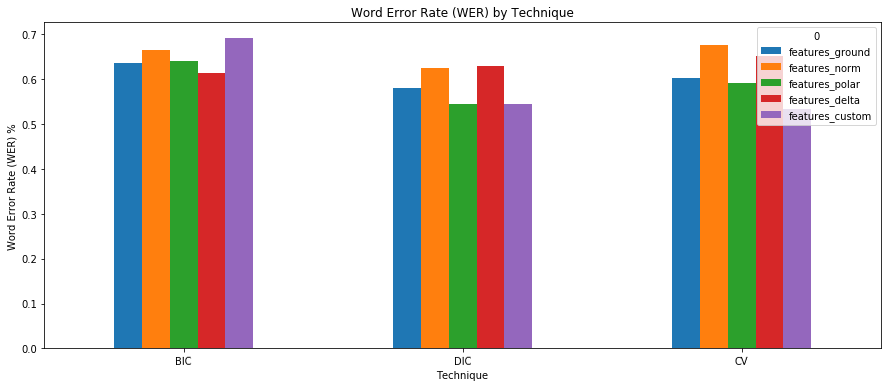

```python
plot = res.set_index(0).T.plot(kind='bar', stacked=False,
                  figsize=(15, 6), rot=1,
                  title="Distribution of Issues")
plot.set_xlabel("Technique")
plot.set_ylabel("Word Error Rate (WER) %")
plot.set_title("Word Error Rate (WER) by Technique")
```

We've squeezed just about as much as we can out of the model and still only get about 50% of the words right! Surely we can do better than that. Probability to the rescue again in the form of [statistical language models (SLM)](https://en.wikipedia.org/wiki/Language_model). The basic idea is that each word has some probability of occurrence within the set, and some probability that it is adjacent to specific other words. We can use that additional information to make better choices.

## Resources

[ go back to the top ]

- [Introduction to N-grams (Stanford Jurafsky slides)](https://web.stanford.edu/class/cs124/lec/languagemodeling.pdf)
- [Speech Recognition Techniques for a Sign Language Recognition System, Philippe Dreuw et al](https://www-i6.informatik.rwth-aachen.de/publications/download/154/Dreuw--2007.pdf) see the improved results of applying LM on *this* data!
- SLM data for *this* ASL dataset